# R ANOVA Notebook

This notebook is designed to get you some practice conducting ANOVAs. First, let’s review some of the basics of ANOVA.

Let’s say you have 2x2 ANOVA. That means you two independent variables (IVs) and each IV has two levels each. For example, your first IV might be gender and the two levels could be male and female. The second IV could be negotiation style and the levels could be extreme and moderate.

When you conduct a 2x2 ANOVA you get three pieces of information.

1. Is the main effect for the first IV significant?
   1. In our example, this would tell us if there is a significant difference between the two levels of gender (male and female)
2. Is the main effect for the second IV significant?
   1. In our example, this would tell us if there is a significant difference between the two levels of negotiation style (extreme and moderate)
3. Is the interaction significant?
   1. In our example, this would tell us if the effect of gender depends on the level of negotiation style (or vice versa)

# R vs. SPSS

By default R and SPSS calculate ANOVAs differently. R defaults to what is called Type 1 sum of squares. SPSS defaults to Type 3 sum of squares. If you want to learn about how these types differ, check out this is informative [blog post](https://mcfromnz.wordpress.com/2011/03/02/anova-type-iiiiii-ss-explained/). Long story, short, Type 3 is the type psychologists want to use.

#### But if we want to use R to conduct ANOVAs with Type 3 sum of squares, we have to do a little extra work. This tutorial will show one way to do this.

# Coding

### Install packages

```r
# This package teaches R how to import SPSS files
if (!require(haven)){
  install.packages("haven", dependencies = TRUE)
  require(haven)
}
# This package has a million useful functions for tidying, cleaning, and reshaping data
if (!require(tidyverse)){
  install.packages("tidyverse", dependencies = TRUE)
  require(tidyverse)
}
# This package has functions for doing Type 3 Sum of Squares ANOVAs
if (!require(afex)){
  install.packages("afex", dependencies = TRUE)
  require(afex)
}
```

[output not shown]

```r
# This package calculates effects sizes for t-tests
if (!require(effsize)){
  install.packages("effsize", dependencies = TRUE)
  require(effsize)
}
# This package has helpful functions for reporting statistics in a manuscript
if (!require(papaja)){
  install.packages("papaja", dependencies = TRUE)
  require(papaja)
}
```

### Import the data file

```r
dataset <- read_sav("https://osf.io/re9yh/download")
```

### View the data file

```r
View(dataset)
```

This dataset is from a study that investigated different types of anti-bias training strategies.

There are six columns.

**Subject**

A unique code for each participant

**Training Type**

A between groups independent variable. There are two types of training: one focused on changing attitudes (value = 2) and the other focused on changing identification (value = 1).

**EC**

A between groups independent variable. There are two goals of training: reduce bias (value = 0) or maintain bias (control) (value = 1)

**IAT Order**

A between groups independent variable. This variable encodes which dependent variable was administered first to each particpant: one focused on attitudes (value = 1) or one focused on identification (value = 2).

**RaceDFeb**

A dependent variable that measures implicit prejudice against Black people

**IdenDFeb**

A dependent variable that measures implicit identification with Black people

And, if you’re paying attention, we can talk about a within-groups variable: implicit bias. There are two levels: attitudes and identification

### Remove duplicate rows

```r
dataset %>% #start with dataset
  distinct(Subject, .keep_all = TRUE) -> dataset.unique
```

## 2x2 between groups ANOVA

The aov_ez function of the afex package will run the Type 3 ANOVA for us. It requires the following information to run a between groups ANOVA.

- **id**: this is a variable with a unique code for each participant
- **dv**: this is the dependent variable
- **data**: this is the data.frame with the data
- **between**: this is a list of the between subjects indpendent variables

```r
(dataset.unique.aov <- aov_ez(id = "Subject", dv = "RaceDFeb", data = dataset.unique, between=c("TrainTyp", "EC")))
```

```
Converting to factor: TrainTyp, EC
Contrasts set to contr.sum for the following variables: TrainTyp, EC
```

```
Anova Table (Type 3 tests)

Response: RaceDFeb
       Effect     df  MSE       F    ges p.value
1    TrainTyp 1, 710 0.16    0.00 <.0001    >.99
2          EC 1, 710 0.16 7.10 **   .010    .008
3 TrainTyp:EC 1, 710 0.16    0.64  .0009     .43
---
Signif. codes:  0 ‘***’ 0.001 ‘**’ 0.01 ‘*’ 0.05 ‘+’ 0.1 ‘ ’ 1
```

Above is the table of statistics related to the ANOVA we just ran. It tells us the three pieces of information that ANOVAs provide:

1. The main effect of TrainTyp is not significant. See row 1. The F value is reported as 0 (it is not 0, just very small) and the p-value is reported as greater than .99. This means that we can’t reject the null hypothesis that the two types of training have a similar effect on implicit prejudice.
2. The main effect of training goal was significant. See row 2. The F value is greater than 7 and the p-value is .008. This means we can reject the null hypothesis that training to reduce bias and training to maintain bias have a similar effect on implicit prejudice.
3. The interaction is not significant. See row 3. The F value is .64 and the p-value is .43. This means the main effect of training goal does not depend on the type of training.

So this table tells us a lot of information but there are still two questions we would like to know the answers to: 1. We know the main effect of training goal is significant. But how large is this effect? We need to run another chunk of code to find out (technically, the column ges is a measure of effect size but it is one that psychologists don’t usually report. We will learn the code to report the effect size statistic that psychologists usually report) 2. We know the main effect of training goal is significant. But we don’t know which condition had less prejudice. Kinda important for a study investigating strategies to reduce bias.

### Effect sizes

Psychologists usually report partial Eta-squared as the effect size associated with F tests like ANOVA. It describes how much variability in the DV is explained by the IV.

Here is how partial eta squared is usually interpreted:

- **small:** greater than .01
- **medium:** greater than .06
- **large:** greater than .14

Below we will use the apa_print() function of the papapja package to report the partial eta squaareds associated with the ANOVA.

### Calculate means and standard deviations

We will use the tidyverse to calculate the means and standard deviations for the two levels of training goal (EC).

```r
(dataset.unique %>% # start with the dataset
  group_by(EC) %>% # group by the training goal variable
  summarise(mean = mean(RaceDFeb), # get the mean of the DV in each group
            SD = sd(RaceDFeb)) -> trainingGoalDescriptives) # get the SD of the DV in each group
```

| EC | mean | SD |
| --- | --- | --- |
| 0 | 0.1496878 | 0.3828941 |
| 1 | 0.2331503 | 0.4209176 |

### APA style write up

Here is how you communicate all this information in an APA style manuscript.

First, we will use the apa_print function of the papaja package to create APA style summaries of statistics.

```r
aov_recall <- apa_print(dataset.unique.aov, es = "pes", in_paren=FALSE) # es = pes is how we get the partial eta squared reproted
```

And we will use this helper function to round variables to 2 decimal places

```r
twoDecimalFormat <- function(val){
  format(round(val, 2), nsmall = 2)
}
```

To examine the effect of training type and training goal on implicit prejudice, we conducted a 2 (training type: change attitudes vs. change identification) $x$ 2 (training goal: reduce bias vs. maintain bias) ANOVA with implicit prejudice as the dependent variable. The main effect of training type, $F(1, 710) = 0.00$, $\mathit{MSE} = 0.16$, $p = .998$, $\hat{\eta}^2_p = .000$, and the interaction between training type and training goal, $F(1, 710) = 0.64$, $\mathit{MSE} = 0.16$, $p = .426$, $\hat{\eta}^2_p = .001$, were not significant. Notably, the main effect of training goal was significant, $F(1, 710) = 7.10$, $\mathit{MSE} = 0.16$, $p = .008$, $\hat{\eta}^2_p = .010$ indicating that participants in the reduce bias training conditions (*M* = 0.15, *SD* = 0.38) had less implicit prejudice than participants in the maintain bias training conditions, *M* = 0.23, *SD* = 0.42.

### Figure

#### Create a single variable with four levels that correspond to the four conditions of the experiment.

```r
dataset.unique %>% #start with dataset
  unite("TrainingTypebyGoal", c("TrainTyp", "EC")) %>% # combine the 2 IV columns
  mutate(TrainingTypebyGoal = if_else(str_detect(TrainingTypebyGoal, "1_0"), "Iden Training, Reduce Bias", TrainingTypebyGoal),
         TrainingTypebyGoal = if_else(str_detect(TrainingTypebyGoal, "1_1"), "Iden Training, Maintain Bias", TrainingTypebyGoal),
         TrainingTypebyGoal = if_else(str_detect(TrainingTypebyGoal, "2_0"), "Attitude Training, Reduce Bias", TrainingTypebyGoal),
         TrainingTypebyGoal = if_else(str_detect(TrainingTypebyGoal, "2_1"), "Attitude Training, Maintain Bias", TrainingTypebyGoal)) -> dataset.unique.plotDF
```

#### Create bar graph

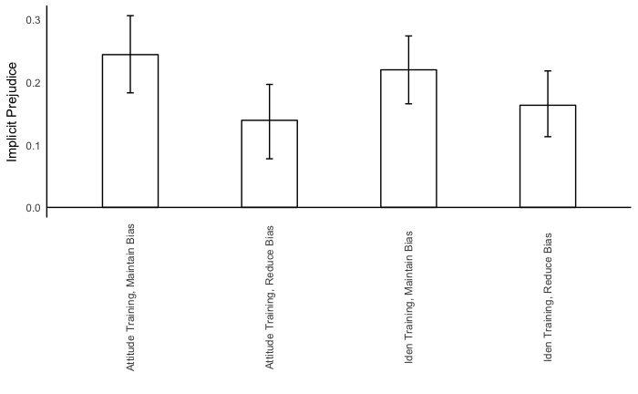

```r
ggplot(dataset.unique.plotDF, aes(x = factor(TrainingTypebyGoal), y=RaceDFeb)) +
  stat_summary(fun.y="mean", geom="bar", width=.4, color="black", fill="white") +
  theme_minimal() +
  theme(panel.grid = element_blank(), axis.line.y = element_line(color="black", size = .5), axis.text.x  = element_text(angle=90, vjust=0.5)) +
  geom_hline(yintercept=0, color="black", size=.5) +
  labs(x = "", y = "Implicit Prejudice") +
  stat_summary(fun.data = "mean_cl_boot", geom="errorbar", width=.05)
```

## 2x2 ANOVA: one IV between, one IV within

If you’re ANOVA has at least one within subjects variable then you need to reshape your dataset from wide to long

```r
dataset.unique %>% # start with dataset
  gather(ImplicitBias, value, -Subject, -TrainTyp, -EC, -IATOrder) -> dataset.unique.long # reshape from wide to long
```

```
attributes are not identical across measure variables;
they will be dropped
```

### ANOVA code

The code is almost the exact same as for between groups ANOVAs. Just add the within= parameter.

```r
(dataset.unique.rm <- aov_ez("Subject","value", dataset.unique.long, between=c("EC"), within=c("ImplicitBias")))
```

```
Converting to factor: EC
Contrasts set to contr.sum for the following variables: EC
```

```
Anova Table (Type 3 tests)

Response: value
           Effect     df  MSE         F  ges p.value
1              EC 1, 712 0.18    6.63 * .005     .01
2    ImplicitBias 1, 712 0.15 30.44 ***  .02  <.0001
3 EC:ImplicitBias 1, 712 0.15      1.71 .001     .19
---
Signif. codes:  0 ‘***’ 0.001 ‘**’ 0.01 ‘*’ 0.05 ‘+’ 0.1 ‘ ’ 1
```

# If the interaction was significant in either ANOVA, this is what we would do

### Estimate marginal means

```r
(ls.within <- lsmeans(dataset.unique.rm, c("EC"), by = c("ImplicitBias")))
```

```
ImplicitBias = RaceDFeb:
 EC     lsmean         SE      df   lower.CL  upper.CL
 0  0.15000758 0.02124888 1412.95 0.10832482 0.1916903
 1  0.23347012 0.02114130 1410.03 0.19199834 0.2749419

ImplicitBias = IdenDFeb:
 EC     lsmean         SE      df   lower.CL  upper.CL
 0  0.06508454 0.02124888 1412.95 0.02340179 0.1067673
 1  0.09578014 0.02114130 1410.03 0.05430836 0.1372519

Confidence level used: 0.95
```

### Test simple Effects

```r
(simple.effects.rm <- update(pairs(ls.within), by=NULL, adjust = "none"))
```

```
 contrast ImplicitBias    estimate       SE      df t.ratio p.value
 0 - 1    RaceDFeb     -0.08346254 0.029975 1411.53  -2.784  0.0054
 0 - 1    IdenDFeb     -0.03069560 0.029975 1411.53  -1.024  0.3060
```

### Calculate the effect size associated with each t-test.

We will calculate cohen’s d for this. It represents the standardized difference between two means. For more information check out [this webpage](http://rpsychologist.com/d3/cohend/).

Here is how Cohen’s d is usually interpreted:

- **small:** greater than .2
- **medium:** greater than .5
- **large:** greater than .8

#### First, we’ll calculate the cohen’s d for when implicit prejudice is the DV

```r
(dataset.unique.long %>%
  filter(ImplicitBias == "RaceDFeb") %>%
   with(effsize::cohen.d(value ~ EC, paired = FALSE, hedges.correction=FALSE, na.rm=TRUE)) -> RaceDFebEffSize)
```

```
Cohercing rhs of formula to factor
```

```
Cohen's d

d estimate: -0.207325 (small)
95 percent confidence interval:
        inf         sup
-0.35467789 -0.05997216
```

#### Now, we’ll calculate the cohen’s d for when identification is the DV

```r
(dataset.unique.long %>%
  filter(ImplicitBias == "IdenDFeb") %>%
   with(effsize::cohen.d(value ~ EC, paired = FALSE, hedges.correction=FALSE, na.rm=TRUE)) -> IdenDFebEffSize)
```

```
Cohercing rhs of formula to factor
```

```
Cohen's d

d estimate: -0.07706167 (negligible)
95 percent confidence interval:
       inf        sup
-0.2240748  0.0699515
```